# Task 2 - Application of predictive models - Final version.

##### Import the relevant libraries

```python
import pandas as pd
import numpy as np
import matplotlib.pyplot as plt
import seaborn as sns
from sklearn.model_selection import train_test_split
from sklearn.preprocessing import LabelEncoder
from sklearn.datasets import make_classification
from sklearn.ensemble import RandomForestClassifier
from sklearn.metrics import classification_report
from imblearn.over_sampling import RandomOverSampler, SMOTE
from imblearn.under_sampling import RandomUnderSampler, NearMiss
from collections import Counter
from sklearn.preprocessing import OneHotEncoder
from scipy.stats import chi2_contingency
import sklearn.metrics as metrics
from sklearn.model_selection import GridSearchCV
from sklearn.metrics import f1_score
from sklearn.metrics import roc_auc_score
from sklearn.metrics import confusion_matrix
from sklearn.linear_model import LogisticRegression
from sklearn.linear_model import SGDClassifier
```

##### Importing the cleaned dataframe from the previous task, reading it and contain it into df variable.

```python
df = pd.read_csv("D:/מבוא למדעי הנתונים/מטלה 1/DF_FINAL.csv")
```

##### Presenting the dataframe

```python
pd.set_option('display.max_columns', None)
df.head()
```

|  | Unnamed: 0 | age | marital_status | ses | weigh | bp_sys | bp_dias | bp_cat | smoking_status | glucose | albumin | ACR | cholesterol_total | LDL | TSH | gravity_u | nitrites_u | proteinuria | MCV | Charlson | framingham_cvd | antidiabetics | ERD | CVD | HTN | immigrant | dead_5y | obesity_status |
| --- | --- | --- | --- | --- | --- | --- | --- | --- | --- | --- | --- | --- | --- | --- | --- | --- | --- | --- | --- | --- | --- | --- | --- | --- | --- | --- | --- | --- |
| 0 | 0 | 49.0 | U | 1 | 2 | 1 | 1 | Normal | non_smoker | 4 | 3.940000 | 3 | 211.6 | 114.0 | 12.5 | 3 | 0.0 | 0.0 | 4 | 1 | 3 | 1 | 0 | 0 | 1 | 0 | 0 | obesity |
| 1 | 1 | 46.0 | M | 1 | 1 | 1 | 2 | Normal | non_smoker | 2 | 4.500000 | 2 | 154.0 | 79.0 | 13.5 | 3 | 0.0 | 0.0 | 1 | 1 | 2 | 1 | 0 | 0 | 0 | 0 | 0 | overweight |
| 2 | 2 | 46.0 | U | 1 | 1 | 4 | 4 | Pre-HTN | non_smoker | 4 | 4.331609 | 3 | 252.0 | 65.0 | 13.8 | 4 | 0.0 | 0.0 | 3 | 1 | 3 | 1 | 0 | 0 | 1 | 0 | 0 | overweight |
| 3 | 3 | 45.0 | U | 2 | 1 | unknown | 1 | Normal | current_smoker | 4 | 4.600000 | 2 | 149.0 | 92.0 | 12.6 | 2 | 0.0 | 0.0 | 3 | 1 | 3 | 1 | 0 | 0 | 0 | 0 | 0 | overweight |
| 4 | 4 | 49.0 | U | 1 | 1 | 1 | 2 | Normal | non_smoker | 3 | 4.400000 | 1 | 178.0 | 94.8 | 11.9 | 4 | 0.0 | 0.0 | 4 | 1 | 1 | 1 | 0 | 0 | 0 | 0 | 0 | healthy |

```python
# for some unknown reason the "Unmanaged:0" row was added to the dataframe, i will delete it
df.drop(['Unnamed: 0'], axis = 1, inplace=True)
```

```python
print("The dataframe's dimensions:")
df.shape
```

```
The dataframe's dimensions:
```

```
(12438, 27)
```

```python
print("The variables type: ")
print("-----------------------------------")
df.info()
```

```
The variables type:
-----------------------------------
<class 'pandas.core.frame.DataFrame'>
RangeIndex: 12438 entries, 0 to 12437
Data columns (total 27 columns):
 #   Column             Non-Null Count  Dtype
---  ------             --------------  -----
 0   age                12438 non-null  float64
 1   marital_status     12438 non-null  object
 2   ses                12438 non-null  int64
 3   weigh              12438 non-null  object
 4   bp_sys             12438 non-null  object
 5   bp_dias            12438 non-null  object
 6   bp_cat             12438 non-null  object
 7   smoking_status     12438 non-null  object
```

[output cut: 21 more lines]

#### Split the variables into category list and numeric list, and transforming the target variable into category datatype for being able to run the models on him.

```python
num_columns = ['age', 'albumin', 'cholesterol_total', 'LDL', 'TSH']
cat_columns = [col for col in df.columns if col not in num_columns]

df.dead_5y = df.dead_5y.astype('category')
```

##### Printing for each variable (column) in cat_column list the sum for each category.

##### Moreover, i added a graphical view of the frequency.

```python
for column in df[cat_columns]:
    print(df[column].value_counts())
    print('--------------------')
```

```
M    8537
U    3901
Name: marital_status, dtype: int64
--------------------
1    6281
2    3890
3    2267
Name: ses, dtype: int64
--------------------
4          3151
3          3123
1          2975
2          2935
unknown     254
Name: weigh, dtype: int64
--------------------
4          3759
1          2766
2          2697
3          2001
unknown    1215
Name: bp_sys, dtype: int64
--------------------
4          5566
2          4110
1          1479
3           759
unknown     524
Name: bp_dias, dtype: int64
--------------------
Normal     7496
Pre-HTN    2809
HTN-G1     1691
HTN-G2      367
HTN-G3       75
Name: bp_cat, dtype: int64
--------------------
non_smoker        7806
current_smoker    3287
past_smoker       1345
```

[output cut: 79 more lines]

```
--------------------
0    10263
1     2175
Name: immigrant, dtype: int64
--------------------
0    12241
1      197
Name: dead_5y, dtype: int64
--------------------
obesity        7089
overweight     3948
healthy        1374
underweight      27
Name: obesity_status, dtype: int64
--------------------
```

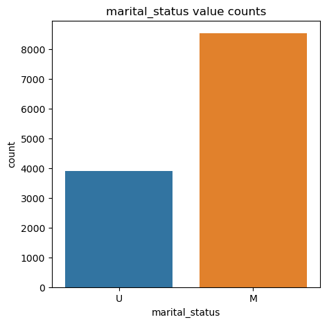

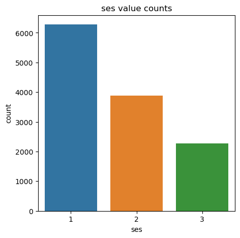

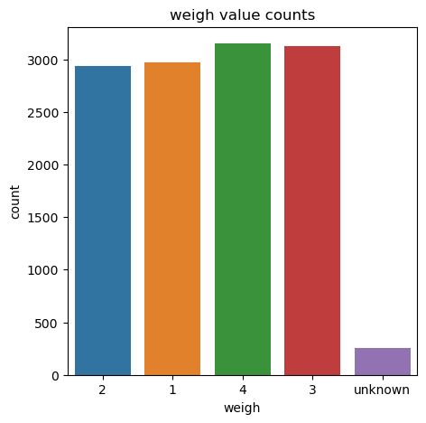

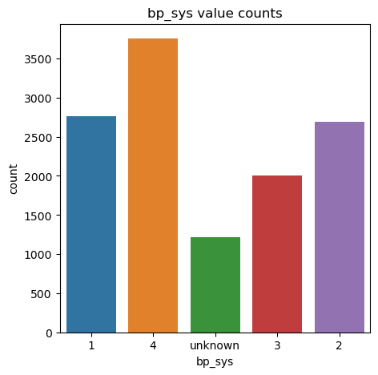

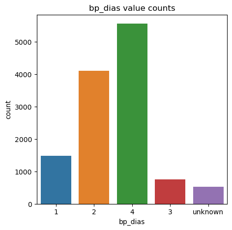

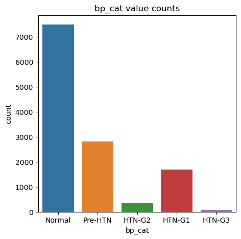

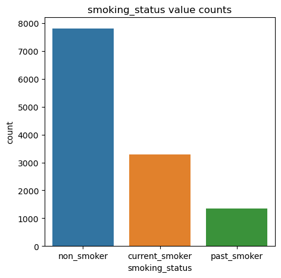

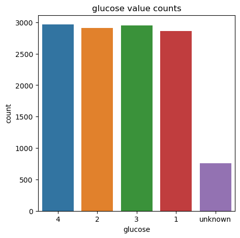

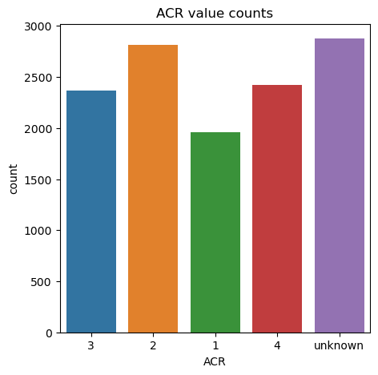

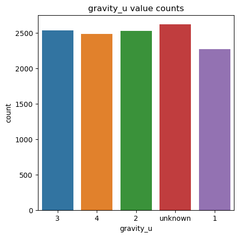

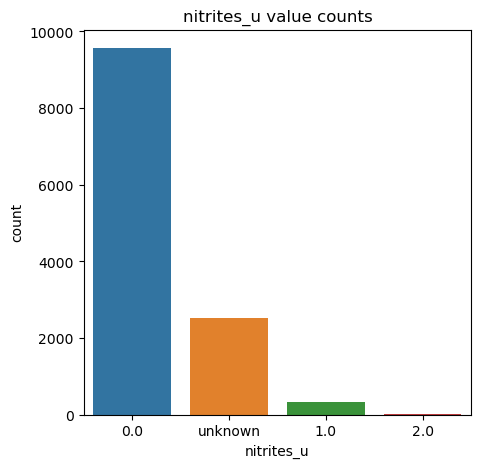

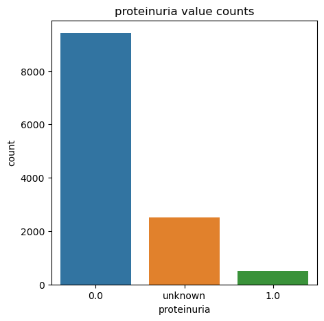

[10 more figures not shown]

```python
for column in df[cat_columns]:
    plt.figure(figsize=(5, 5))
    sns.countplot(x=column, data=df)
    plt.title(f"{column} value counts")
    plt.show()
```

##### I want to make sure that all the categorial vairables will be an integer tatatype beacue we need that the models will work on them well.

##### Moreover, i noticed after analyzing the countplot that the variables "smoking_status" and "proteinuria" are not binar, i will handel them soon beacuse it is not good for our model calculation over these not binar variables.

```python
LE = LabelEncoder()

for col in cat_columns:
    # Encode the categorical column as integers
    df[col] = LE.fit_transform(df[col])
df.dead_5y = df.dead_5y.astype('category')
```

```python
df.info()
```

```
<class 'pandas.core.frame.DataFrame'>
RangeIndex: 12438 entries, 0 to 12437
Data columns (total 27 columns):
 #   Column             Non-Null Count  Dtype
---  ------             --------------  -----
 0   age                12438 non-null  float64
 1   marital_status     12438 non-null  int32
 2   ses                12438 non-null  int64
 3   weigh              12438 non-null  int32
 4   bp_sys             12438 non-null  int32
 5   bp_dias            12438 non-null  int32
 6   bp_cat             12438 non-null  int32
 7   smoking_status     12438 non-null  int32
 8   glucose            12438 non-null  int32
 9   albumin            12438 non-null  float64
```

[output cut: 19 more lines]

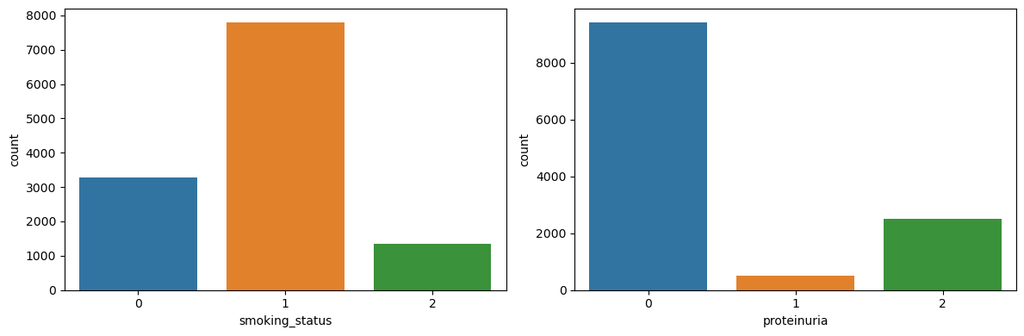

```python
# Count-plotting the problematic variables before, as non binar

fig, (ax1, ax2) = plt.subplots(1, 2, figsize=(12, 4))

sns.countplot(x="smoking_status", data=df, ax=ax1)
sns.countplot(x="proteinuria", data=df, ax=ax2)

plt.tight_layout()
plt.show()
```

```python
df.smoking_status.value_counts(), df.proteinuria.value_counts()
```

```
(1    7806
 0    3287
 2    1345
 Name: smoking_status, dtype: int64,
 0    9428
 2    2506
 1     504
 Name: proteinuria, dtype: int64)
```

##### I handeled the problem by transforming the categorical columns specified in the "cols_to_encoder" list using one-hot encoding and adding the encoded columns to the dataframe, while dropping the original categorical columns.

```python
cols_to_encoder = ['smoking_status', 'proteinuria']
df = pd.get_dummies(df, columns=cols_to_encoder, prefix=cols_to_encoder, prefix_sep="_")
df[df.columns[-6:]] = df[df.columns[-6:]].astype(float)
```

```python
df.head()
```

|  | age | marital_status | ses | weigh | bp_sys | bp_dias | bp_cat | glucose | albumin | ACR | cholesterol_total | LDL | TSH | gravity_u | nitrites_u | MCV | Charlson | framingham_cvd | antidiabetics | ERD | CVD | HTN | immigrant | dead_5y | obesity_status | smoking_status_0 | smoking_status_1 | smoking_status_2 | proteinuria_0 | … |
| --- | --- | --- | --- | --- | --- | --- | --- | --- | --- | --- | --- | --- | --- | --- | --- | --- | --- | --- | --- | --- | --- | --- | --- | --- | --- | --- | --- | --- | --- | --- |
| 0 | 49.0 | 1 | 0 | 1 | 0 | 0 | 3 | 3 | 3.940000 | 2 | 211.6 | 114.0 | 12.5 | 2 | 0 | 3 | 1 | 2 | 1 | 0 | 0 | 1 | 0 | 0 | 1 | 0.0 | 1.0 | 0.0 | 1.0 | … |
| 1 | 46.0 | 0 | 0 | 0 | 0 | 1 | 3 | 1 | 4.500000 | 1 | 154.0 | 79.0 | 13.5 | 2 | 0 | 0 | 1 | 1 | 1 | 0 | 0 | 0 | 0 | 0 | 2 | 0.0 | 1.0 | 0.0 | 1.0 | … |
| 2 | 46.0 | 1 | 0 | 0 | 3 | 3 | 4 | 3 | 4.331609 | 2 | 252.0 | 65.0 | 13.8 | 3 | 0 | 2 | 1 | 2 | 1 | 0 | 0 | 1 | 0 | 0 | 2 | 0.0 | 1.0 | 0.0 | 1.0 | … |
| 3 | 45.0 | 1 | 1 | 0 | 4 | 0 | 3 | 3 | 4.600000 | 1 | 149.0 | 92.0 | 12.6 | 1 | 0 | 2 | 1 | 2 | 1 | 0 | 0 | 0 | 0 | 0 | 2 | 1.0 | 0.0 | 0.0 | 1.0 | … |
| 4 | 49.0 | 1 | 0 | 0 | 0 | 1 | 3 | 2 | 4.400000 | 0 | 178.0 | 94.8 | 11.9 | 3 | 0 | 3 | 1 | 0 | 1 | 0 | 0 | 0 | 0 | 0 | 0 | 0.0 | 1.0 | 0.0 | 1.0 | … |

```python
# checking the dataframe after the change i additional way

df.info()
```

```
<class 'pandas.core.frame.DataFrame'>
RangeIndex: 12438 entries, 0 to 12437
Data columns (total 31 columns):
 #   Column             Non-Null Count  Dtype
---  ------             --------------  -----
 0   age                12438 non-null  float64
 1   marital_status     12438 non-null  int32
 2   ses                12438 non-null  int64
 3   weigh              12438 non-null  int32
 4   bp_sys             12438 non-null  int32
 5   bp_dias            12438 non-null  int32
 6   bp_cat             12438 non-null  int32
 7   glucose            12438 non-null  int32
 8   albumin            12438 non-null  float64
 9   ACR                12438 non-null  int32
```

[output cut: 23 more lines]

```python
print("The dataframe's current dimensions:")
df.shape
```

```
The dataframe's current dimensions:
```

```
(12438, 31)
```

```python
cat_columns = [col for col in df.columns if col not in num_columns and col != 'dead_5y']
```

##### For all the divisions, I define a constant random number (seed) so that every division that is made will always be the same.

```python
# Create X and y variables
X = df.drop("dead_5y", axis=1)
y = df['dead_5y']

# Divide the data into train and test sets
X_train, X_test, y_train, y_test = train_test_split(X, y, test_size=0.2, random_state=35)

# Divide the training set into train and dev sets
X_train, X_dev, y_train, y_dev = train_test_split(X_train, y_train, test_size=0.3, random_state=35)
```

```python
# view the dimensions

X_train.shape, X_test.shape, X_dev.shape
```

```
((6965, 30), (2488, 30), (2985, 30))
```

##### In a moment, i will check the relative balance of the "y" values between the three groups using the chi-squared test, which means i will verify if the "y" values will be distributed relatively evenly between the three groups.

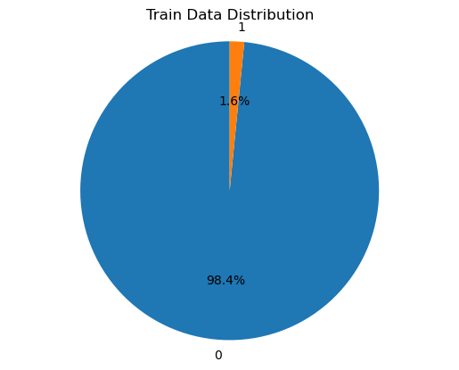

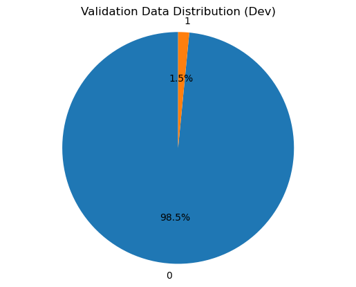

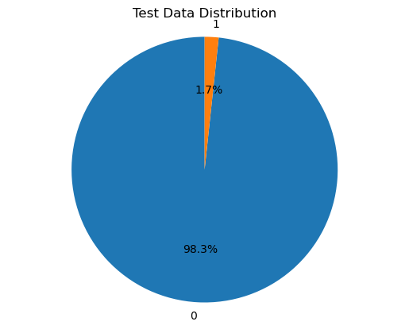

```python
def plot_pie_chart(data, title):
    labels = data.index
    plt.pie(data, labels=labels, autopct='%1.1f%%', startangle=90)
    plt.axis('equal')
    plt.title(title)
    plt.show()


train_data = y_train.value_counts(normalize=True)
plot_pie_chart(train_data, 'Train Data Distribution')

dev_data = y_dev.value_counts(normalize=True)
plot_pie_chart(dev_data, 'Validation Data Distribution (Dev)')

test_data = y_test.value_counts(normalize=True)
plot_pie_chart(test_data, 'Test Data Distribution')
```

```python
outcome_0_counts = [sum(y_train == 0), sum(y_dev == 0), sum(y_test == 0)]
outcome_1_counts = [sum(y_train == 1), sum(y_dev == 1), sum(y_test == 1)]

data_table = [outcome_0_counts, outcome_1_counts]
chi2, p, dof, expected = chi2_contingency(data_table)

print("Chi-squared test statistic:", chi2)
print("p-value:", p)
```

```
Chi-squared test statistic: 0.22450731949964184
p-value: 0.8938175032181039
```

##### I can see that there is a tiny difference between these groups, i mean that there is a low significats level.

##### Now Im going to make the same examination on the binar ones in these groups.

##### I will select the categorical variables from the X_train, X_dev, and X_test data sets.

##### Then, I will use these variables to create a contingency table for each categorical variable.

##### And then I will perform the chi-squared test on each contingency table to determine whether there is a significant association between the variables.

```python
import pandas as pd
from scipy.stats import chi2_contingency

# Select the categorical variables from x_train, x_dev, and x_test
x_train_categorical = X_train[cat_columns]
x_dev_categorical = X_dev[cat_columns]
x_test_categorical = X_test[cat_columns]

# Create a contingency table for each categorical variable
tables = {}
for col in x_train_categorical.columns:
    data_table = pd.crosstab(index=x_train_categorical[col], columns="count")
    data_table["Dev"] = pd.crosstab(index=x_dev_categorical[col], columns="count")
    data_table["Test"] = pd.crosstab(index=x_test_categorical[col], columns="count")
    tables[col] = data_table

    # Perform the chi-squared test on each contingency table
    chi2, p, dof, expected = chi2_contingency(data_table)
    print(f"Chi-squared test statistic for {col}: {chi2}")
    print(f"p-value for {col}: {p}")
    print("-" * 50)

    # Print the contingency table
    print(f"Contingency table for {col}:")
    print(data_table)
    print("=" * 50)
```

```
Chi-squared test statistic for marital_status: 0.5004344978309538
p-value for marital_status: 0.778631607823145
--------------------------------------------------
Contingency table for marital_status:
col_0           count   Dev  Test
marital_status
0                4780  2037  1720
1                2185   948   768
==================================================
Chi-squared test statistic for ses: 4.168332276086181
p-value for ses: 0.38370363323299145
--------------------------------------------------
Contingency table for ses:
col_0  count   Dev  Test
ses
0       3565  1466  1250
1       2137   961   792
2       1263   558   446
==================================================
Chi-squared test statistic for weigh: 2.3506549995713293
p-value for weigh: 0.9683316582356553
--------------------------------------------------
Contingency table for weigh:
col_0  count  Dev  Test
weigh
0       1660  715   600
1       1628  710   597
2       1760  743   620
3       1765  763   623
4        152   54    48
==================================================
Chi-squared test statistic for bp_sys: 13.154182456035551
p-value for bp_sys: 0.10665363897893754
--------------------------------------------------
Contingency table for bp_sys:
col_0   count  Dev  Test
bp_sys
0        1553  655   558
1        1462  662   573
2        1107  474   420
```

[output cut: 214 more lines]

```
Contingency table for proteinuria_1:
col_0          count   Dev  Test
proteinuria_1
0.0             6695  2863  2376
1.0              270   122   112
==================================================
Chi-squared test statistic for proteinuria_2: 1.8239452465924888
p-value for proteinuria_2: 0.4017309780170166
--------------------------------------------------
Contingency table for proteinuria_2:
col_0          count   Dev  Test
proteinuria_2
0.0             5532  2397  2003
1.0             1433   588   485
==================================================
```

#### According to the results, the split that was made between the three data sets is balanced.

##### Now I need to verify if the distribution of the target variable (Y values) is balanced within the training set. If the proportion of 1's in the target variable is less than 15%, then we should perform balancing on the training set.

```
0    12241
1      197
Name: dead_5y, dtype: int64
```

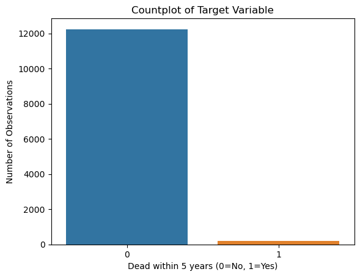

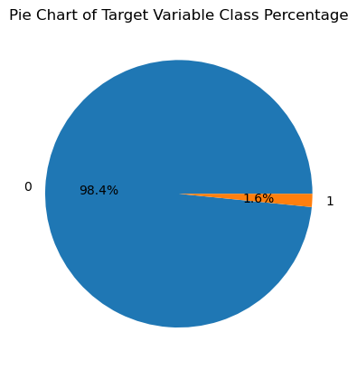

```python
# Count the number of observations for each class of the target variable
class_counts = df['dead_5y'].value_counts()

# Print the class counts
print(class_counts)

# Plot a countplot
sns.countplot(x='dead_5y', data=df)
plt.title('Countplot of Target Variable')
plt.xlabel('Dead within 5 years (0=No, 1=Yes)')
plt.ylabel('Number of Observations')
plt.show()

# Calculate the percentage of observations in each class
class_percentages = class_counts / class_counts.sum()

# Plot a pie chart of the class percentages
plt.pie(class_percentages, labels=class_percentages.index, autopct='%1.1f%%')
plt.title('Pie Chart of Target Variable Class Percentage')
plt.show()
```

##### Hence, I'll apply resampling techniques (Undersampling, Oversampling, and SMOTE) individually on the preprocessed training dataset.

```
[(0, 6856), (1, 6856)]
```

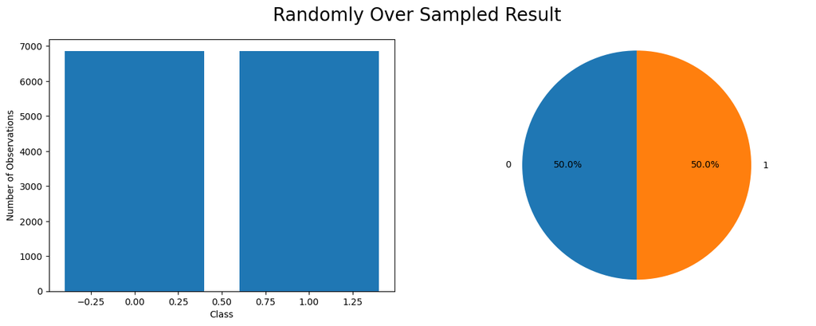

```python
# Randomly over sample the minority class
ros = RandomOverSampler(random_state=46)
X_train_ros, y_train_ros= ros.fit_resample(X_train, y_train)

# Check the number of records after over sampling
result = sorted(Counter(y_train_ros).items())
print(result)


class_labels, class_counts = zip(*result)

# Plotting the result as a bar graph
fig, ax = plt.subplots(nrows=1, ncols=2, figsize=(15, 5))
ax[0].bar(class_labels, class_counts)
ax[0].set_xlabel('Class')
ax[0].set_ylabel('Number of Observations')

# Plotting the result as a pie chart
ax[1].pie(class_counts, labels=class_labels, startangle=90, autopct='%1.1f%%')
ax[1].axis('equal')

plt.suptitle('Randomly Over Sampled Result', fontsize=20)
plt.show()
```

```
[(0, 109), (1, 109)]
```

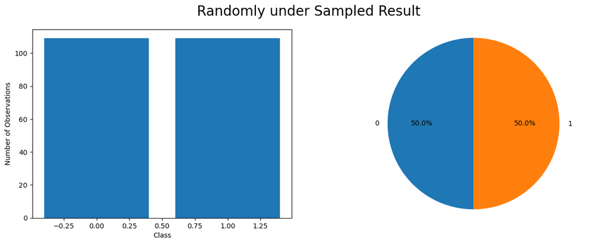

```python
# Randomly under sample the majority class
rus = RandomUnderSampler(random_state=46)
X_train_rus, y_train_rus= rus.fit_resample(X_train, y_train)

# Check the number of records after over sampling
result = sorted(Counter(y_train_rus).items())
print(result)


class_labels, class_counts = zip(*result)

# Plotting the result as a bar graph
fig, ax = plt.subplots(nrows=1, ncols=2, figsize=(15, 5))
ax[0].bar(class_labels, class_counts)
ax[0].set_xlabel('Class')
ax[0].set_ylabel('Number of Observations')

# Plotting the result as a pie chart
ax[1].pie(class_counts, labels=class_labels, startangle=90, autopct='%1.1f%%')
ax[1].axis('equal')

plt.suptitle('Randomly under Sampled Result', fontsize=20)
plt.show()
```

```
[(0, 6856), (1, 6856)]
```

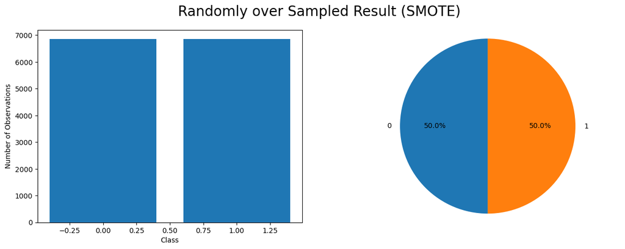

```python
# Randomly over sample the minority class
smote = SMOTE(random_state=46)
X_train_smote, y_train_smote= smote.fit_resample(X_train, y_train)

# Check the number of records after over sampling
result = sorted(Counter(y_train_smote).items())
print(result)


class_labels, class_counts = zip(*result)

# Plotting the result as a bar graph
fig, ax = plt.subplots(nrows=1, ncols=2, figsize=(15, 5))
ax[0].bar(class_labels, class_counts)
ax[0].set_xlabel('Class')
ax[0].set_ylabel('Number of Observations')

# Plotting the result as a pie chart
ax[1].pie(class_counts, labels=class_labels, startangle=90, autopct='%1.1f%%')
ax[1].axis('equal')

plt.suptitle('Randomly over Sampled Result (SMOTE)', fontsize=20)
plt.show()
```

##### Considering the unbalanced nature of the data, accuracy would not be the most suitable metric to evaluate the performance of the classifier. Instead, we opt to use the AUC (Area Under the Receiver Operating Characteristic Curve) to evaluate the model's ability to distinguish between positive and negative examples. AUC ranges from 0.5 for a random classifier to 1 for a perfect classifier.

##### In unbalanced datasets, AUC is a preferred metric as it takes into account both the true positive rate (TPR) and false positive rate (FPR) of a binary classification model, making it insensitive to class imbalance. In this case, we chose the logistic regression model and calculated its AUC for each method.

##### With the AUC metric selected as the evaluation method for our binary classification model, i will apply the logistic regression algorithm to each sample method. The AUC metric considers both the true positive rate and false positive rate of the model, providing a single number summary of performance that is not affected by class imbalance. This is particularly important in our case, as class 1 is significantly underrepresented (1.6%) compared to class 0 (98.4%). The AUC metric provides a more accurate measurement of model performance compared to accuracy in unbalanced datasets.

```python
lr = LogisticRegression(penalty='l2', C = 1)

# Randomly over sample the minority class
ros = RandomOverSampler(random_state=46)
X_train_ros, y_train_ros = ros.fit_resample(X_train, y_train)

# Randomly under sample the majority class
rus = RandomUnderSampler(random_state=46)
X_train_rus, y_train_rus = rus.fit_resample(X_train, y_train)

# Apply Synthetic Minority Over-sampling Technique (SMOTE)
smote = SMOTE(random_state=46)
X_train_smote, y_train_smote = smote.fit_resample(X_train, y_train)

# Fit the Logistic Regression model to the over-sampled data
lr.fit(X_train_ros, y_train_ros)
y_pred_prob_dev = lr.predict_proba(X_dev)[:,1]
y_pred_prob_train = lr.predict_proba(X_train)[:,1]
over_dev_auc = roc_auc_score(y_dev, y_pred_prob_dev)
over_train_auc = roc_auc_score(y_train, y_pred_prob_train)

# Fit the Logistic Regression model to the under-sampled data
lr.fit(X_train_rus, y_train_rus)
y_pred_prob_dev = lr.predict_proba(X_dev)[:,1]
y_pred_prob_train = lr.predict_proba(X_train)[:,1]
under_dev_auc = roc_auc_score(y_dev, y_pred_prob_dev)
under_train_auc = roc_auc_score(y_train, y_pred_prob_train)

# Fit the Logistic Regression model to the SMOTE data
lr.fit(X_train_smote, y_train_smote)
y_pred_prob_dev = lr.predict_proba(X_dev)[:,1]
y_pred_prob_train = lr.predict_proba(X_train)[:,1]
smote_dev_auc = roc_auc_score(y_dev, y_pred_prob_dev)
smote_train_auc = roc_auc_score(y_train, y_pred_prob_train)

# Print the AUC scores
print("Over-sampled train AUC:", over_train_auc)
print("Over-sampled dev AUC:", over_dev_auc)
print('--------------------------------------------')
print("Under-sampled train AUC:", under_train_auc)
print("Under-sampled dev AUC:", under_dev_auc)
print('--------------------------------------------')
print("SMOTE train AUC:", smote_train_auc)
print("SMOTE dev AUC:", smote_dev_auc)
```

```
Over-sampled train AUC: 0.8128860544035628
Over-sampled dev AUC: 0.7930159622468452
--------------------------------------------
Under-sampled train AUC: 0.7973809855159346
Under-sampled dev AUC: 0.7763288311611461
--------------------------------------------
SMOTE train AUC: 0.6968757025253445
SMOTE dev AUC: 0.6973090521768718
```

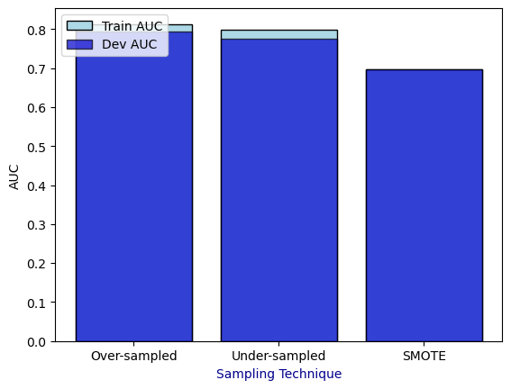

```python
sampling_techniques = ['Over-sampled', 'Under-sampled', 'SMOTE']
train_f1 = [over_train_auc, under_train_auc, smote_train_auc]
dev_f1 = [over_dev_auc, under_dev_auc, smote_dev_auc]

x_pos = np.arange(len(sampling_techniques))

fig, ax = plt.subplots()
ax.bar(x_pos, train_f1, color='lightblue', edgecolor='black', label='Train AUC')
ax.bar(x_pos, dev_f1, color='mediumblue', edgecolor='black', label='Dev AUC', alpha=0.7)

ax.set_xticks(x_pos)
ax.set_xticklabels(sampling_techniques)
ax.set_ylabel('AUC')
ax.set_xlabel('Sampling Technique', color='darkblue')
plt.legend(loc='upper left')

plt.show()
```

##### Based on these results, the Over-sampled model performed better in terms of accuracy, as evidenced by its higher AUC score on both the training and dev datasets. The difference between the training and dev AUC scores for the Over-sampled model is also smaller compared to the Under-sampled model, indicating that the Over-sampled model has better generalization performance and is less likely to overfit the training data.

##### Therefore, the Over-sampled model was chosen as the best option among the three models, despite the SMOTE model having a smaller difference between the training and dev AUC scores, due to its lower overall accuracy. In comparison, the SMOTE model had a significantly lower AUC score on both the training and dev datasets, which makes it a less suitable choice for this scenario.

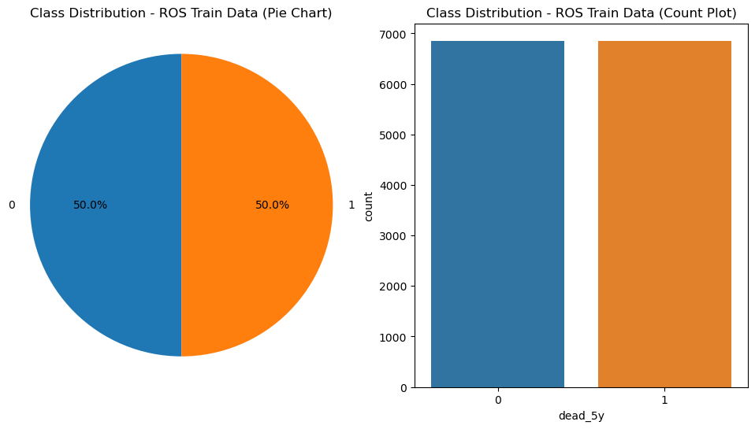

```python
X_train, y_train = X_train_ros, y_train_ros
# Pie Chart
labels = y_train.value_counts().index
sizes = y_train.value_counts().values

fig, (ax1, ax2) = plt.subplots(1, 2, figsize=(12,6))
ax1.pie(sizes, labels=labels, autopct='%1.1f%%', startangle=90)
ax1.axis('equal')  # Equal aspect ratio ensures that pie is drawn as a circle
ax1.set_title('Class Distribution - ROS Train Data (Pie Chart)')

# Count Plot
sns.countplot(x=y_train, ax=ax2)
ax2.set_title('Class Distribution - ROS Train Data (Count Plot)')

plt.show()
```

## Using supervised models

##### My approach involves training models on a designated training set, which are then applied to both the training and development sets for evaluation.

```python
models_results = pd.DataFrame()
```

## Logistic Regression

```python
lr = LogisticRegression(penalty="none")
lr.fit(X_train, y_train)

lr_train_prob = lr.predict_proba(X_train)[:,1]
lr_train_auc = roc_auc_score(y_train, lr_train_prob)

lr_dev_prob = lr.predict_proba(X_dev)[:,1]
lr_dev_auc = roc_auc_score(y_dev, lr_dev_prob)

lr_model_results = {'model': "Logistic Regression", 'AUC-train': lr_train_auc, 'AUC-dev': lr_dev_auc}
models_results = models_results.append(lr_model_results, ignore_index=True)
models_results
```

|  | model | AUC-train | AUC-dev |
| --- | --- | --- | --- |
| 0 | Logistic Regression | 0.815072 | 0.792927 |

```python
lr_dev_pred = (lr_dev_prob >= 0.5).astype(int)
pd.crosstab(y_dev, lr_dev_pred)
```

| col_0 dead_5y | 0 | 1 |
| --- | --- | --- |
| 0 | 2120 | 819 |
| 1 | 13 | 33 |

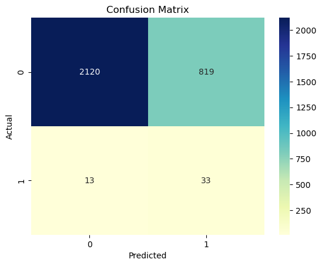

```python
conf_matrix = pd.crosstab(y_dev, lr_dev_pred)
sns.heatmap(conf_matrix, annot=True, fmt='d', cmap="YlGnBu")
plt.xlabel('Predicted')
plt.ylabel('Actual')
plt.title('Confusion Matrix')
plt.show()
```

## Gradient Descent

```python
sgd = SGDClassifier(loss='log')
sgd.fit(X_train, y_train)

sgd_train_prob = sgd.predict_proba(X_train)[:,1]
sgd_train_auc = roc_auc_score(y_train, sgd_train_prob)

sgd_dev_prob = sgd.predict_proba(X_dev)[:,1]
sgd_dev_auc = roc_auc_score(y_dev, sgd_dev_prob)

sgd_model_results = {'model': "Gradient Descent", 'AUC-train': sgd_train_auc, 'AUC-dev': sgd_dev_auc}
models_results = models_results.append(sgd_model_results, ignore_index=True)
models_results
```

|  | model | AUC-train | AUC-dev |
| --- | --- | --- | --- |
| 0 | Logistic Regression | 0.815072 | 0.792927 |
| 1 | Gradient Descent | 0.781337 | 0.748706 |

```python
sgd_dev_pred = (sgd_dev_prob >= 0.5).astype(int)
pd.crosstab(y_dev, sgd_dev_pred)
```

| col_0 dead_5y | 0 | 1 |
| --- | --- | --- |
| 0 | 1549 | 1390 |
| 1 | 8 | 38 |

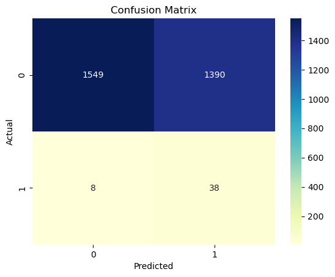

```python
conf_matrix = pd.crosstab(y_dev, sgd_dev_pred)
sns.heatmap(conf_matrix, annot=True, fmt='d', cmap="YlGnBu")
plt.xlabel('Predicted')
plt.ylabel('Actual')
plt.title('Confusion Matrix')
plt.show()
```

## Lasso

```python
lasso = LogisticRegression(penalty='l1', solver='saga')
lasso.fit(X_train, y_train)

lasso_train_prob = lasso.predict_proba(X_train)[:,1]
lasso_train_auc = roc_auc_score(y_train, lasso_train_prob)

lasso_dev_prob = lasso.predict_proba(X_dev)[:,1]
lasso_dev_auc = roc_auc_score(y_dev, lasso_dev_prob)

lasso_model_results = {'model': "LASSO", 'AUC-train': lasso_train_auc, 'AUC-dev': lasso_dev_auc}
models_results = models_results.append(lasso_model_results, ignore_index=True)
models_results
```

|  | model | AUC-train | AUC-dev |
| --- | --- | --- | --- |
| 0 | Logistic Regression | 0.815072 | 0.792927 |
| 1 | Gradient Descent | 0.781337 | 0.748706 |
| 2 | LASSO | 0.812696 | 0.799577 |

```python
lasso_dev_pred = (lasso_dev_prob >= 0.5).astype(int)
pd.crosstab(y_dev, lasso_dev_pred)
```

| col_0 dead_5y | 0 | 1 |
| --- | --- | --- |
| 0 | 2138 | 801 |
| 1 | 10 | 36 |

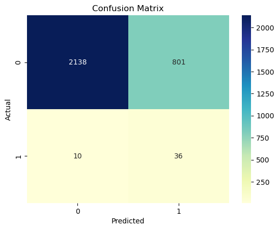

```python
conf_matrix = pd.crosstab(y_dev, lasso_dev_pred)
sns.heatmap(conf_matrix, annot=True, fmt='d', cmap="YlGnBu")
plt.xlabel('Predicted')
plt.ylabel('Actual')
plt.title('Confusion Matrix')
plt.show()
```

## Ridge

```python
ridge = LogisticRegression(penalty='l2', solver='saga')
ridge.fit(X_train, y_train)

ridge_train_prob = ridge.predict_proba(X_train)[:,1]
ridge_train_auc = roc_auc_score(y_train, ridge_train_prob)

ridge_dev_prob = ridge.predict_proba(X_dev)[:,1]
ridge_dev_auc = roc_auc_score(y_dev, ridge_dev_prob)

ridge_model_results = {'model': "RIDGE", 'AUC-train': ridge_train_auc, 'AUC-dev': ridge_dev_auc}
models_results = models_results.append(ridge_model_results, ignore_index=True)
models_results
```

|  | model | AUC-train | AUC-dev |
| --- | --- | --- | --- |
| 0 | Logistic Regression | 0.815072 | 0.792927 |
| 1 | Gradient Descent | 0.781337 | 0.748706 |
| 2 | LASSO | 0.812696 | 0.799577 |
| 3 | RIDGE | 0.812738 | 0.799525 |

```python
ridge_dev_pred = (ridge_dev_prob >= 0.5).astype(int)
pd.crosstab(y_dev, ridge_dev_pred)
```

| col_0 dead_5y | 0 | 1 |
| --- | --- | --- |
| 0 | 2141 | 798 |
| 1 | 10 | 36 |

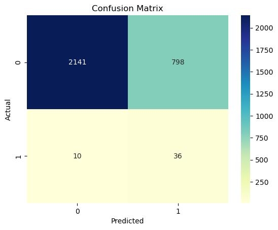

```python
conf_matrix = pd.crosstab(y_dev, ridge_dev_pred)
sns.heatmap(conf_matrix, annot=True, fmt='d', cmap="YlGnBu")
plt.xlabel('Predicted')
plt.ylabel('Actual')
plt.title('Confusion Matrix')
plt.show()
```

## Elasticnet

```python
elasticnet = LogisticRegression(penalty='elasticnet', solver='saga', l1_ratio=0.5)
elasticnet.fit(X_train, y_train)

elasticnet_train_prob = elasticnet.predict_proba(X_train)[:,1]
elasticnet_train_auc = roc_auc_score(y_train, elasticnet_train_prob)

elasticnet_dev_prob = elasticnet.predict_proba(X_dev)[:,1]
elasticnet_dev_auc = roc_auc_score(y_dev, elasticnet_dev_prob)

elasticnet_model_results = {'model': "Elastic Net", 'AUC-train': elasticnet_train_auc, 'AUC-dev': elasticnet_dev_auc}
models_results = models_results.append(elasticnet_model_results, ignore_index=True)
models_results
```

|  | model | AUC-train | AUC-dev |
| --- | --- | --- | --- |
| 0 | Logistic Regression | 0.815072 | 0.792927 |
| 1 | Gradient Descent | 0.781337 | 0.748706 |
| 2 | LASSO | 0.812696 | 0.799577 |
| 3 | RIDGE | 0.812738 | 0.799525 |
| 4 | Elastic Net | 0.812753 | 0.799525 |

```python
elasticnet_dev_pred = (elasticnet_dev_prob >= 0.5).astype(int)
pd.crosstab(y_dev, elasticnet_dev_pred)
```

| col_0 dead_5y | 0 | 1 |
| --- | --- | --- |
| 0 | 2138 | 801 |
| 1 | 10 | 36 |

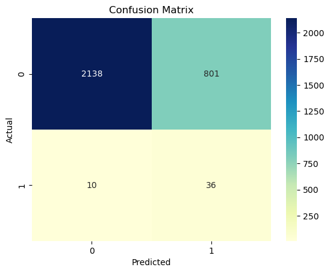

```python
conf_matrix = pd.crosstab(y_dev, elasticnet_dev_pred)
sns.heatmap(conf_matrix, annot=True, fmt='d', cmap="YlGnBu")
plt.xlabel('Predicted')
plt.ylabel('Actual')
plt.title('Confusion Matrix')
plt.show()
```

##### The final table:

```python
models_results
```

|  | model | AUC-train | AUC-dev |
| --- | --- | --- | --- |
| 0 | Logistic Regression | 0.815072 | 0.792927 |
| 1 | Gradient Descent | 0.781337 | 0.748706 |
| 2 | LASSO | 0.812696 | 0.799577 |
| 3 | RIDGE | 0.812738 | 0.799525 |
| 4 | Elastic Net | 0.812753 | 0.799525 |

##### Additionally, logistic regression is a well-established and interpretable model that is commonly used in many applications, which makes it a suitable choice in this context.

##### Therefore, I chose to use the logistic regression model for this task.

##### I will now run the model on the untouched test data and present the results.

```python
lr = LogisticRegression()
lr.fit(X_train, y_train)

lr_train_probs = lr.predict_proba(X_train)[:,1]
lr_train_auc = metrics.roc_auc_score(y_train, lr_train_probs)

lr_dev_probs = lr.predict_proba(X_dev)[:,1]
lr_dev_auc = metrics.roc_auc_score(y_dev, lr_dev_probs)

lr_test_probs = lr.predict_proba(X_test)[:,1]
lr_test_auc = metrics.roc_auc_score(y_test, lr_test_probs)

print("Train AUC:", lr_train_auc)
print("Dev AUC:", lr_dev_auc)
print("Test AUC:", lr_test_auc)
```

```
Train AUC: 0.8158565128415997
Dev AUC: 0.7930159622468452
Test AUC: 0.8023206011758751
```

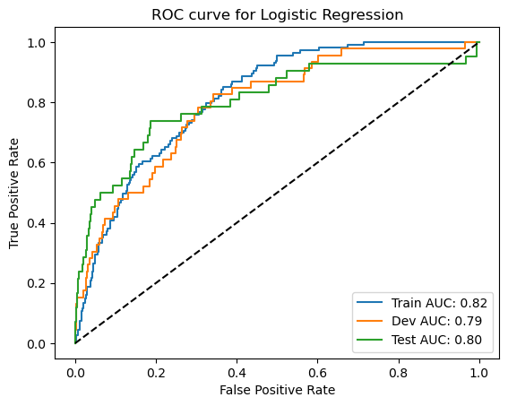

```python
from sklearn.metrics import roc_auc_score, roc_curve

# Generate ROC curve for train set
fpr_train, tpr_train, thresholds_train = roc_curve(y_train, lr_train_probs)
roc_auc_train = roc_auc_score(y_train, lr_train_probs)

# Generate ROC curve for dev set
fpr_dev, tpr_dev, thresholds_dev = roc_curve(y_dev, lr_dev_probs)
roc_auc_dev = roc_auc_score(y_dev, lr_dev_probs)

# Generate ROC curve for test set
fpr_test, tpr_test, thresholds_test = roc_curve(y_test, lr_test_probs)
roc_auc_test = roc_auc_score(y_test, lr_test_probs)

# Plot ROC curve for train set
plt.plot(fpr_train, tpr_train, label='Train AUC: %0.2f'% roc_auc_train)

# Plot ROC curve for dev set
plt.plot(fpr_dev, tpr_dev, label='Dev AUC: %0.2f'% roc_auc_dev)

# Plot ROC curve for test set
plt.plot(fpr_test, tpr_test, label='Test AUC: %0.2f'% roc_auc_test)

# Plot the reference line
plt.plot([0, 1], [0, 1], 'k--')

# Set the axis labels and title
plt.xlabel('False Positive Rate')
plt.ylabel('True Positive Rate')
plt.title('ROC curve for Logistic Regression')

# Show the legend
plt.legend(loc='lower right')

# Show the plot
plt.show()
```

##### The AUC (Area Under the Receiver Operating Characteristic) score is a commonly used metric to evaluate the performance of a binary classifier. In the case of these results, the AUC scores for the train set, dev set, and test set are 0.8158565128415997, 0.7930159622468452, and 0.8023206011758751, respectively.

##### A score of 1.0 represents a perfect classifier, while a score of 0.5 represents a random classifier. A good classifier will have a high AUC score, close to 1.0, indicating that it is able to distinguish between positive and negative classes well.

##### In this case, the train AUC score is higher than the dev and test AUC scores. This is generally expected, as the model has been trained on the training data, and will perform better on that data. However, the difference between the train and dev/test AUC scores is relatively small, indicating that the model is not overfitting the training data, and generalizes well to new data.

##### The AUC scores of 0.79 and 0.80 for the dev and test sets respectively, indicate that the Logistic Regression model is performing well in classifying the target variable based on the input features.